# Marxists Internet Archive LDA

fuente: https://github.com/DiegoKoz/MIA_text_mining

> Warning: Este dataset es muy pesado. Eso implica que lleva tiempo correr los modelos y que puede no entrar en la memoria de la computadora. Para la clase, se puede hacer un muestreo de textos para que no pese tanto

```r
library(igraph)
```

```r
df <- read_csv('../data/txt/texto_limpio.txt')
# df <- read_rds('data/MIA.RDS')
df <- df %>%
  filter(tipo=='notas')
```

```r
df <- df %>%
  mutate(texto = tolower(texto),
         texto = stri_trans_general(texto, "Latin-ASCII"),
         texto = str_trim(texto,side = 'both'),
         texto = str_replace_all(texto,'\t',' '),
         texto = str_replace_all(texto,'\n',' '),
         texto = str_replace_all(texto,'\r',' '),
         texto = str_replace_all(texto,'[[:punct:]]',' '),
         texto = str_replace_all(texto,'\\d','NUM'),
         texto = str_replace_all(texto,'(NUM)+','NUM'),
         texto = str_replace_all(texto,"\\s+", " "))
```

Para topic modeling las palabras comunes de la lengua generan mucho ruido y terminan predominnado en los topicos.

Vamos a eliminar no solo las Stop Words, sino también las palabras más utilizadas en el español que no están relacionadas con nuestra temática. Para eso, tenemos un archivo r_words.txt donde pusimos todas las palabras más comunes.

Además, aprovechamos para eliminar los tokens que quedaron del scrapeo que en realidad son parte del código html (ver final del archivo).

¿de donde salieron estos tokens? En una primera iteración del LDA, uno de los tópicos que se armó era de código html.

```r
palabras_comunes <- read_csv(file = 'data/r_words.txt',col_names = F)
palabras_comunes <-stri_trans_general(palabras_comunes$X1, "Latin-ASCII") # le tengo que hacer la misma transformacion que al texto
stop_words <- stri_trans_general(stopwords(kind = "es"), "Latin-ASCII")

palabras_eliminar <- unique(c(stop_words,palabras_comunes))

rm(stop_words)
rm(palabras_comunes)
gc()
```

```r
Corpus = VCorpus(VectorSource(df$texto))
Corpus = tm_map(Corpus, removeWords, palabras_eliminar)
# Corpus <- tm_map(Corpus, stemDocument, language = "spanish") # Corpus

dtm <- DocumentTermMatrix(Corpus)
rm(Corpus)
gc()
tm::nTerms(dtm)
#elimino los docuemntos vacios
# rowTotals <- apply(dtm , 1, sum)
rowTotals <- rowSums(as.matrix(dtm))
nDocs(dtm)
dtm   <- dtm[rowTotals> 0, ]
nDocs(dtm)

write_rds(dtm, 'data/dtm_MIA.rds')

df <- df[which(rowTotals>0),] #%>%  #tengo que eliminar ese docuemnto que estaba vacio
```

```r
1
```

```
[1] 1
```

limpio la memoria porque ya no me queda espacio

```r
rm(palabras_eliminar)
gc()
```

```r
lda_fit <- LDA(dtm, k = 10,method = "Gibbs", control = list(delta=0.6,seed = 1234))
lda_fit

saveRDS(lda_fit, 'modelos/MIA_lda.rds') # Tarda mucho en correr, asi que guardamos los resultados
```

```r
lda_fit <- read_rds('modelos/MIA_lda.rds')
```

```r
Terms
```

```
      Topic 1      Topic 2        Topic 3     Topic 4      Topic 5      Topic 6        Topic 7        Topic 8             Topic 9     Topic 10
 [1,] "rda"        "num"          "num"       "ejercito"   "num"        "num"          "mao"          "num"               "espana"    "num"
 [2,] "balcanes"   "partido"      "stalin"    "guerra"     "trabajo"    "pueblo"       "china"        "numpt"             "hombres"   "lenin"
 [3,] "balcanicos" "revolucion"   "trotsky"   "militares"  "produccion" "gobierno"     "imperialismo" "pnum"              "casa"      "carta"
 [4,] "turquia"    "lucha"        "comite"    "frente"     "sociedad"   "chile"        "argentina"    "numcm"             "poum"      "marx"
 [5,] "balcanica"  "politica"     "partido"   "rojo"       "ser"        "trabajadores" "bolivia"      "escritos"          "espanol"   "engels"
 [6,] "bulgaria"   "clase"        "moscu"     "militar"    "sino"       "pais"         "yanqui"       "titulo"            "espanoles" "primera"
 [7,] "rfa"        "proletariado" "oposicion" "pueblo"     "social"     "popular"      "guerrillas"   "sectionnum"        "cataluna"  "edicion"
 [8,] "turcos"     "guerra"       "gpu"       "sovietico"  "vida"       "presidente"   "tse"          "tituloescritosnum" "noche"     "escrito"
 [9,] "ted"        "masas"        "central"   "rusia"      "todas"      "companeros"   "tung"         "tnum"              "tiempo"    "tomo"
[10,] "bulgaro"    "poder"        "lenin"     "campesinos" "hombre"     "nacional"     "albania"      "internacional"     "madrid"    "obras"
```

Visualizacion

```r
topicmodels_json_ldavis <- function(fitted, dtm){
    svd_tsne <- function(x) tsne(svd(x)$u)

    # Find required quantities
    phi <- as.matrix(posterior(fitted)$terms)
    theta <- as.matrix(posterior(fitted)$topics)
    vocab <- colnames(phi)
    term_freq <- slam::col_sums(dtm)

    # Convert to json
    json_lda <- LDAvis::createJSON(phi = phi, theta = theta,
                            vocab = vocab,
                            mds.method = svd_tsne,
                            plot.opts = list(xlab="tsne", ylab=""),
                            doc.length = as.vector(table(dtm$i)),
                            term.frequency = term_freq)

    return(json_lda)
}
```

```r
json_res <- topicmodels_json_ldavis(lda_fit, dtm)

serVis(json_res)
```

# Se puede calcular el tema del que habla en promedio cada autor.

```r
sum(duplicated(fechas[,c("autor", "titulo")]))
```

```
[1] 0
```

| autor | fecha | 1 | 2 | 3 | 4 | 5 | 6 | 7 | 8 | 9 | 10 |
| --- | --- | --- | --- | --- | --- | --- | --- | --- | --- | --- | --- |
| Albert Mathiez | 1920 | 0.00662251655629139 | 0.494205298013245 | 0.054635761589404 | 0.124172185430464 | 0.263245033112583 | 0.0339403973509934 | 0.00538079470198675 | 0.00372516556291391 | 0.00827814569536424 | 0.00579470198675497 |
| Albert Rhys Williams | 1921 | 0.0080091533180778 | 0.265446224256293 | 0.123569794050343 | 0.163615560640732 | 0.0274599542334096 | 0.0995423340961098 | 0.011441647597254 | 0.011441647597254 | 0.268878718535469 | 0.0205949656750572 |
| Alberto Flores Galindo | 1979 | 0.0103289512649472 | 0.376042068479026 | 0.0556372673106638 | 0.0163484116533192 | 0.12417343664924 | 0.105103619226577 | 0.217105041571514 | 0.0477252331309324 | 0.025248089375658 | 0.0222878813381227 |
| Alejandra Kollontai | 1917 | 0.0180677182178657 | 0.218870308545409 | 0.0373280777545605 | 0.0296502804696937 | 0.527666084160343 | 0.0493342852703867 | 0.0182301971283291 | 0.0154311785921979 | 0.0669927667594116 | 0.0184291031018034 |
| Aleksandr Voronsky | 1925 | 0.0847457627118644 | 0.0847457627118644 | 0.11864406779661 | 0.135593220338983 | 0.0847457627118644 | 0.101694915254237 | 0.0847457627118644 | 0.11864406779661 | 0.101694915254237 | 0.0847457627118644 |
| Amadeo Bordiga | 1921 | 0.0130390312554045 | 0.681600366924792 | 0.01695586867343 | 0.0114523456923074 | 0.1868712496458 | 0.026189952723495 | 0.0116883868759338 | 0.0127377187454335 | 0.0206533232013306 | 0.0188117562620739 |
| Ana Pauker | 1947 | 0.108949416342412 | 0.21011673151751 | 0.124513618677043 | 0.116731517509728 | 0.0272373540856031 | 0.0505836575875486 | 0.0389105058365759 | 0.1284046692607 | 0.0466926070038911 | 0.147859922178988 |
| Anatoli Lunacharsky | 1921 | 0.0179096750683346 | 0.181719870832671 | 0.0838519829884192 | 0.0576179973296742 | 0.347796988268552 | 0.0734291848962536 | 0.0239983532906635 | 0.0220955791401439 | 0.132455477583186 | 0.0591248906021017 |
| Andreu Nin | 1933 | 0.0103784890444258 | 0.756620034931291 | 0.0188445413241608 | 0.0180019073870972 | 0.0552316311976541 | 0.0338164352988369 | 0.0112800063123718 | 0.0119745892402096 | 0.0634262388128878 | 0.0204261264510646 |
| Anton Pannekoek | 1929 | 0.00524292828845853 | 0.574102337035898 | 0.00725362319540059 | 0.0102194403632484 | 0.357804918135519 | 0.017335624916214 | 0.00538162155630015 | 0.00717816738589045 | 0.00674904061201187 | 0.00873229851105891 |

[output cut: 127 more lines]

```r
topicos_tsne <- tsne(dist_topicos[3:12],k = 2)
```

```
sigma summary: Min. : 0.430727468238337 |1st Qu. : 0.548366866001167 |Median : 0.61742698372085 |Mean : 0.653490995750656 |3rd Qu. : 0.724654859227475 |Max. : 1.15501487810963 |
Epoch: Iteration #100 error is: 14.2655050814228
Epoch: Iteration #200 error is: 0.440619622443334
Epoch: Iteration #300 error is: 0.405540400540634
Epoch: Iteration #400 error is: 0.32434053810722
Epoch: Iteration #500 error is: 0.317794036564693
Epoch: Iteration #600 error is: 0.315020920259938
Epoch: Iteration #700 error is: 0.314931284731474
Epoch: Iteration #800 error is: 0.314922444810501
Epoch: Iteration #900 error is: 0.314922416082746
Epoch: Iteration #1000 error is: 0.31492241531991
```

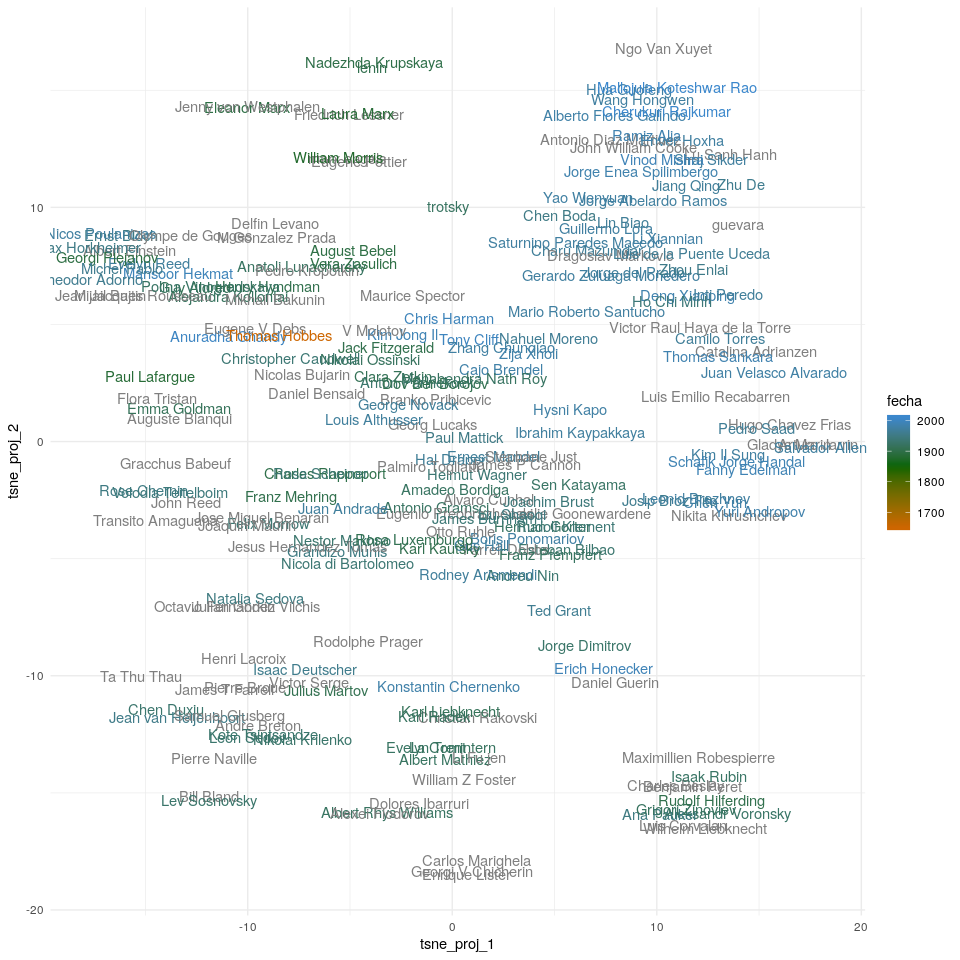

```r
topicos_tsne <- as_tibble(topicos_tsne,.name_repair = ~glue('tsne_proj_{c(1,2)}'))

dist_topicos %>% bind_cols(topicos_tsne) %>%
  ggplot(aes(tsne_proj_1,tsne_proj_2, label=autor, color=fecha)) +
  geom_text()+
  theme_minimal()+
  scale_color_gradient2(low = 'darkorange3',mid ='darkgreen' , high = 'dodgerblue', midpoint = 1850)
```

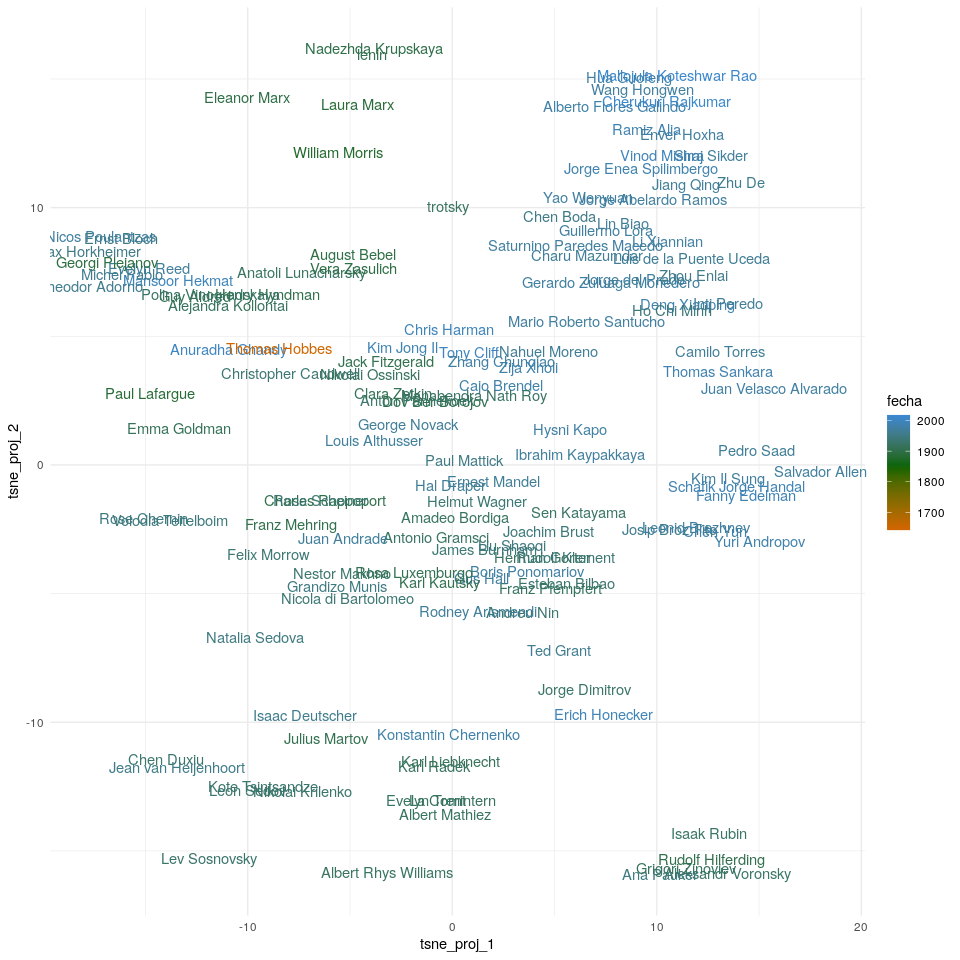

```r
dist_topicos %>% bind_cols(topicos_tsne) %>%
  filter(!is.na(fecha)) %>%
  ggplot(aes(tsne_proj_1,tsne_proj_2, label=autor, color=fecha)) +
  geom_text()+
  theme_minimal()+
  scale_color_gradient2(low = 'darkorange3',mid ='darkgreen' , high = 'dodgerblue', midpoint = 1850)
```

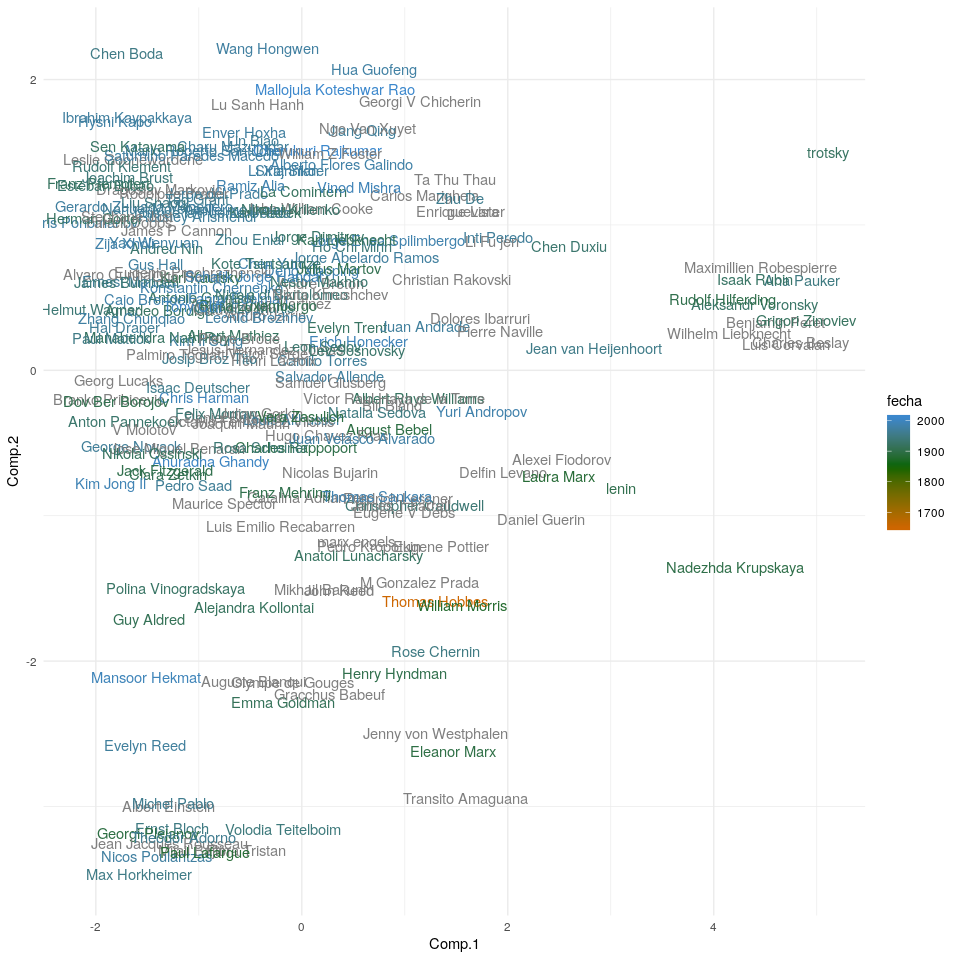

```r
topicos_pca <- princomp(dist_topicos[3:12], cor = TRUE)

dist_topicos %>% bind_cols(as_tibble(topicos_pca$scores[,1:2])) %>%
  ggplot(aes(Comp.1,Comp.2, label=autor, color = fecha)) +
  geom_text()+
  theme_minimal()+
  scale_color_gradient2(low = 'darkorange3',mid ='darkgreen' , high = 'dodgerblue', midpoint = 1850)
```

```r
NA
NA
```

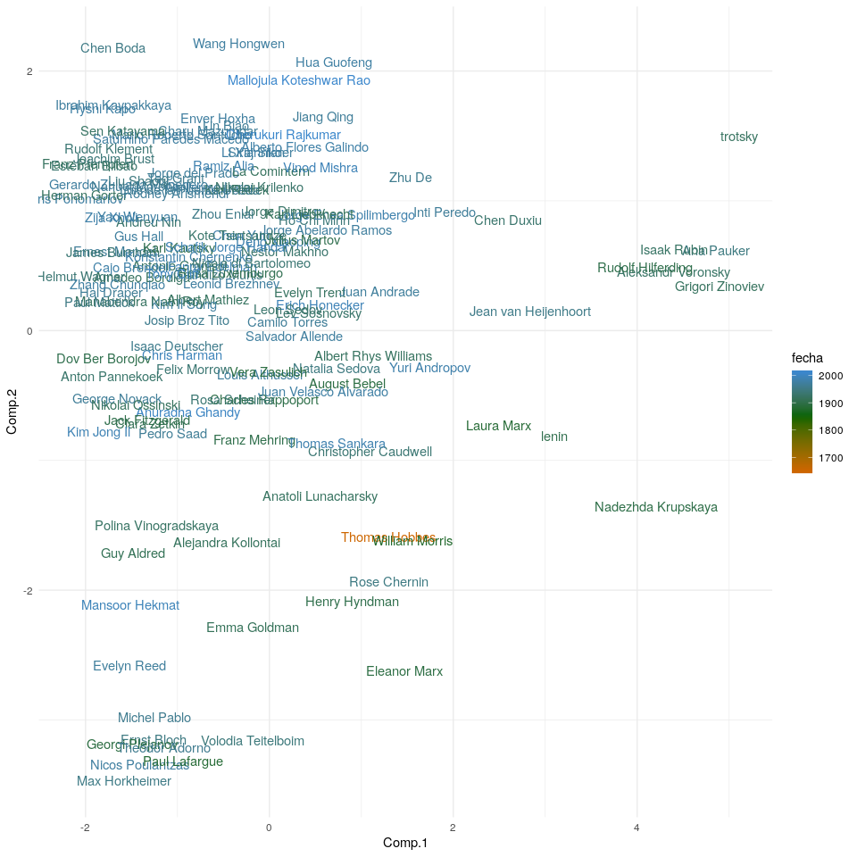

```r
dist_topicos %>% bind_cols(as_tibble(topicos_pca$scores[,1:2])) %>%
  filter(!is.na(fecha)) %>%
  ggplot(aes(Comp.1,Comp.2, label=autor, color = fecha)) +
  geom_text()+
  theme_minimal()+
  scale_color_gradient2(low = 'darkorange3',mid ='darkgreen' , high = 'dodgerblue', midpoint = 1850)
```

## Por fecha

```r
dist_topicos <- df  %>%
  select(autor, fecha) %>%
  bind_cols(as_tibble(as.matrix(posterior(lda_fit)$topics)))
```

[figure not shown]

obs: El dataset tiene mucho de Allende, Tópico 6. Tal vez habria que subsamplear.

```r
Terms
```

```
      Topic 1      Topic 2        Topic 3     Topic 4      Topic 5      Topic 6        Topic 7        Topic 8             Topic 9     Topic 10
 [1,] "rda"        "num"          "num"       "ejercito"   "num"        "num"          "mao"          "num"               "espana"    "num"
 [2,] "balcanes"   "partido"      "stalin"    "guerra"     "trabajo"    "pueblo"       "china"        "numpt"             "hombres"   "lenin"
 [3,] "balcanicos" "revolucion"   "trotsky"   "militares"  "produccion" "gobierno"     "imperialismo" "pnum"              "casa"      "carta"
 [4,] "turquia"    "lucha"        "comite"    "frente"     "sociedad"   "chile"        "argentina"    "numcm"             "poum"      "marx"
 [5,] "balcanica"  "politica"     "partido"   "rojo"       "ser"        "trabajadores" "bolivia"      "escritos"          "espanol"   "engels"
 [6,] "bulgaria"   "clase"        "moscu"     "militar"    "sino"       "pais"         "yanqui"       "titulo"            "espanoles" "primera"
 [7,] "rfa"        "proletariado" "oposicion" "pueblo"     "social"     "popular"      "guerrillas"   "sectionnum"        "cataluna"  "edicion"
 [8,] "turcos"     "guerra"       "gpu"       "sovietico"  "vida"       "presidente"   "tse"          "tituloescritosnum" "noche"     "escrito"
 [9,] "ted"        "masas"        "central"   "rusia"      "todas"      "companeros"   "tung"         "tnum"              "tiempo"    "tomo"
[10,] "bulgaro"    "poder"        "lenin"     "campesinos" "hombre"     "nacional"     "albania"      "internacional"     "madrid"    "obras"
```

## grafo de autores

```r
dist_topicos_autor <- dist_topicos %>%
  group_by(autor) %>%
  summarise_all(~mean(.x, na.rm = T)) %>%
  mutate(fecha=round(fecha))

adjMat = cosine(t(as.matrix(dist_topicos_autor[,3:11])))

colnames(adjMat) <- dist_topicos_autor$autor
rownames(adjMat) <- dist_topicos_autor$autor

adjMat[1:5,1:5]
```

```
                       Albert Einstein Albert Mathiez Albert Rhys Williams Alberto Flores Galindo Alejandra Kollontai
Albert Einstein              1.0000000      0.5176801            0.1214481              0.3299723           0.9378993
Albert Mathiez               0.5176801      1.0000000            0.6704073              0.8423114           0.7624615
Albert Rhys Williams         0.1214481      0.6704073            1.0000000              0.6395057           0.4110921
Alberto Flores Galindo       0.3299723      0.8423114            0.6395057              1.0000000           0.5941258
Alejandra Kollontai          0.9378993      0.7624615            0.4110921              0.5941258           1.0000000
```

```r
fivenum(adjMat)
```

```
[1] 0.01288848 0.48193919 0.72277927 0.88308623 1.00000000
```

```r
#la paso a dicotomica, no quiero que me quede muy densa, asi que pongo como punto de corte alguito apenas el tercer cuartil
adjMat[adjMat>0.89] <- 1
adjMat[adjMat<0.89] <- 0

adjMat[1:5,1:5]
```

```
                       Albert Einstein Albert Mathiez Albert Rhys Williams Alberto Flores Galindo Alejandra Kollontai
Albert Einstein                      1              0                    0                      0                   1
Albert Mathiez                       0              1                    0                      0                   0
Albert Rhys Williams                 0              0                    1                      0                   0
Alberto Flores Galindo               0              0                    0                      1                   0
Alejandra Kollontai                  1              0                    0                      0                   1
```

```r
g = graph_from_adjacency_matrix(adjMat, weighted= NULL, mode="undirected", diag=FALSE)

V(g)$fecha <- dist_topicos_autor$fecha #agrego la fecha como atributo de cada autor
```

```r
mean(degree(g))
```

```
[1] 48.80569
```

```
partial argument match of 'length' to 'length.out'partial argument match of 'frame' to 'frame.plot'
```

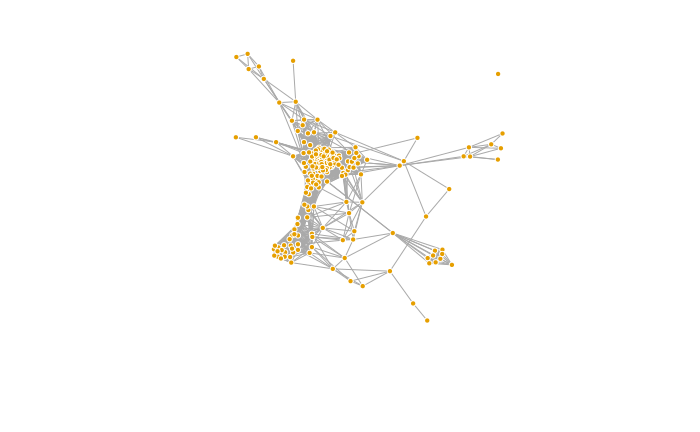

```r
plot(g,edge.arrow.size=.2, vertex.size=4,vertex.frame.color="#ffffff",
             vertex.label="", vertex.label.color="black",
             layout=l)
```

```
Using `nicely` as default layout
```

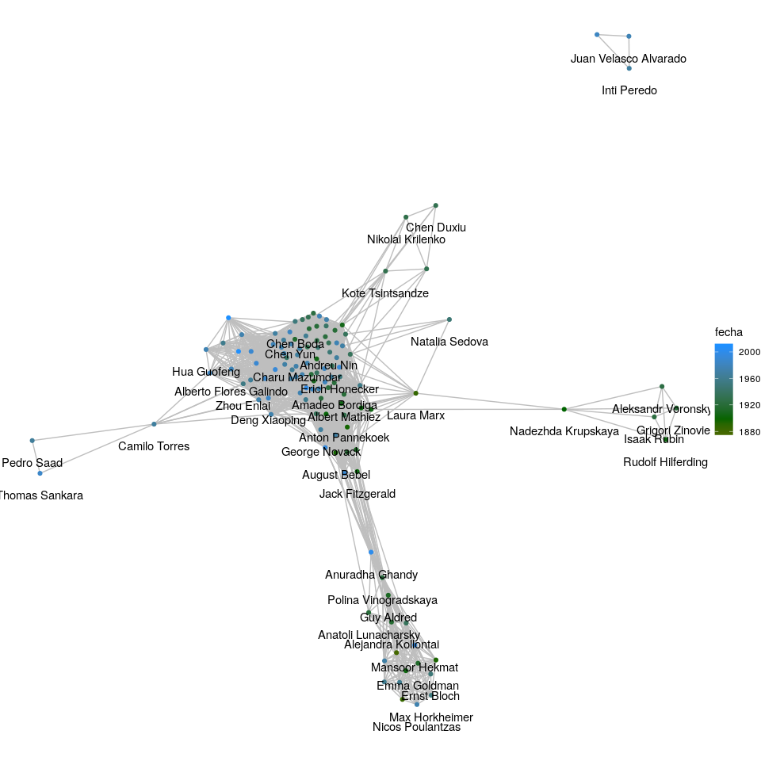

```r
as_tbl_graph(g) %>%
  filter(fecha>1800) %>%
  activate(nodes) %>%
  mutate(importance = centrality_degree()) %>%
  filter(importance >1) %>%
# as_tbl_graph(g) %>%
#   filter(fecha>1800,
#          !degree(g)<2) %>%
ggraph() +
    geom_edge_link(color='grey') +
    geom_node_point(aes(color=fecha))+
    geom_node_text(aes(label=name),check_overlap = T,nudge_y =-.5 ) +
  theme_void()+
  scale_color_gradient2(low = 'darkorange3',mid ='darkgreen' , high = 'dodgerblue', midpoint = 1900)
```